# Solar module I-V

The following table gives the parameters of a solar panel.

| Parameter | Value |
| --- | --- |
| $P_{max}$ (W) | 320 |
| Voltage at $P_{max}$ (V) | 33.4 |
| Current at $P_{max}$ (A) | 9.59 |
| $V_{OC}$ at STC (V) | 40.9 |
| $I_{SC}$ at STC (A) | 10.15 |
| Temperature coefficient for $I_{SC}$ ($\%/^oC$) | 0.058 |
| Temperature coefficient for $V_{OC}$ ($\%/^oC$) | -0.32 |
| Number of cells in series ($N_C$) | 60 |

The solar panel, operating at Standard Test Conditions (STC), is connected to a resistive load with $R = 10\,\Omega$ through a boost converter as shown in the figure. The parameters of the boost converter are $L = 10\,$mH, $C = 1000\,\mu$F, $f_s = 10\,$kHz. Determine the following.

1. the duty ratio of the boost converter for transferring maximum power from the solar panel to the load.
2. the average load voltage.

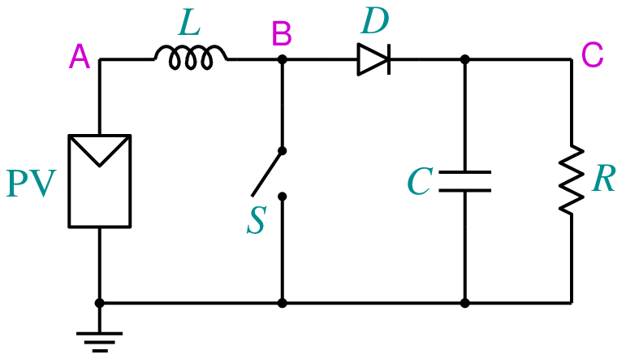

```python
from IPython.display import Image
Image(filename =r'solar_2_fig_1.png', width=300)
```

```python
# run this cell to view the circuit file.
%pycat solar_2_orig.in
```

We now replace the strings such as \$Voc_ref with the values of our choice by running the python script given below. It takes an existing circuit file `solar_2_orig.in` and produces a new circuit file `solar_2.in`, after replacing \$Voc_ref, etc. with values of our choice.

```python
import gseim_calc as calc

s_g_rad = '1000'
s_t_C = '25'
s_Nc = '60'
s_Voc_ref = '40.9'
s_Isc_ref = '10.15'
s_Vm_ref = '33.4'
s_Im_ref = '9.59'
s_coef_Isc = '0.058'
s_coef_Voc = '-0.32'
s_L = '10e-3'
s_C = '1000e-6'
s_R = '10'
s_D = '0.3' # to be changed by user

l = [
  ('$g_rad', s_g_rad),
  ('$t_C', s_t_C),
  ('$Nc', s_Nc),
  ('$Voc_ref', s_Voc_ref),
  ('$Isc_ref', s_Isc_ref),
  ('$Vm_ref', s_Vm_ref),
  ('$Im_ref', s_Im_ref),
  ('$coef_Isc', s_coef_Isc),
  ('$coef_Voc', s_coef_Voc),
  ('$L', s_L),
  ('$C', s_C),
  ('$R', s_R),
  ('$D', s_D),
]
calc.replace_strings_1("solar_2_orig.in", "solar_2.in", l)
print('solar_2.in is ready for execution')
```

```
solar_2.in is ready for execution
```

**Execute the following cell to run GSEIM on solar_2.in.**

```python
import os
import dos_unix
# uncomment for windows:
#dos_unix.d2u("solar_2.in")
os.system('run_gseim solar_2.in')
```

```
Circuit: filename = solar_2.in
main: calling solve_sss
solve_sss starting: sss_n_st: 3
solve_sss_ex: sss_iter_newton=0, rhs_sss_norm=4.7000e-01, sss_period_1_compute=2.0000e-04
solve_sss_ex: sss_iter_newton=1, rhs_sss_norm=1.2485e-02, sss_period_1_compute=2.0000e-04
solve_sss_ex: sss_iter_newton=2, rhs_sss_norm=1.1503e-04, sss_period_1_compute=2.0000e-04
solve_sss_ex: sss_iter_newton=3, rhs_sss_norm=1.7998e-07, sss_period_1_compute=2.0000e-04
solve_sss_ex: sss_iter_newton=4, rhs_sss_norm=2.7588e-10, sss_period_1_compute=2.0000e-04
solve_sss_ex: sss_iter_newton=5, rhs_sss_norm=4.2203e-13, sss_period_1_compute=2.0000e-04
solve_sss_ex: calling sss_solve_trns_ex for one more trns step
Transient simulation starts...
i=0
GSEIM: Program completed.
```

```
0
```

The circuit file (`solar_2.in`) is created in the same directory as that used for launching Jupyter notebook. The last step (i.e., running `GSEIM` on `solar_2.in`) creates a data file called `solar_2.dat` in the same directory. We can now use the python code below to compute/plot the various quantities of interest.

```
filename: solar_2.dat
average voltage across R:  5.2324E+01
average power delivered to R:  2.7378E+02
```

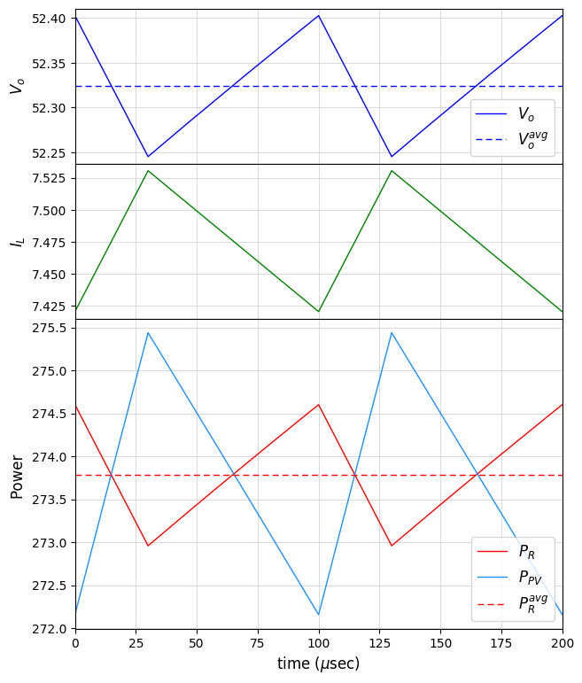

```python
import numpy as np
import matplotlib.pyplot as plt
import gseim_calc as calc
from setsize import set_size

f_hz = 10.0e3
T = 1.0/f_hz

slv = calc.slv("solar_2.in")

i_slv = 0
i_out = 0
filename = slv.l_filename_all[i_slv][i_out]
print('filename:', filename)
u = np.loadtxt(filename)
t = u[:, 0]

IL    = slv.get_array_double(i_slv,i_out,"IL",u)
v_out = slv.get_array_double(i_slv,i_out,"v_out",u)
P_R   = slv.get_array_double(i_slv,i_out,"P_R",u)
Psrc  = slv.get_array_double(i_slv,i_out,"Psrc",u)

v_out_avg = calc.avg_3(t, v_out, 0.0, 2.0*T, 1.0e-4*T)
P_R_avg   = calc.avg_3(t, P_R  , 0.0, 2.0*T, 1.0e-4*T)
Psrc_avg  = calc.avg_3(t, Psrc , 0.0, 2.0*T, 1.0e-4*T)

print('average voltage across R:', "%11.4E"%(v_out_avg))
print('average power delivered to R:', "%11.4E"%(P_R_avg))

color1 = 'blue'
color2 = 'green'
color3 = 'red'
color4 = 'dodgerblue'
color5 = 'olive'

fig, ax = plt.subplots(3, sharex=False, gridspec_kw={'height_ratios': [1, 1, 2]})
plt.subplots_adjust(wspace=0, hspace=0.0)

set_size(5.5, 7, ax[0])

for i in range(3):
    ax[i].set_xlim(left=0.0, right=2.0*T*1e6)
    ax[i].grid(color='#CCCCCC', linestyle='solid', linewidth=0.5)

ax[0].set_ylabel(r'$V_o$', fontsize=12)
ax[1].set_ylabel(r'$I_L$', fontsize=12)
ax[2].set_ylabel('Power ', fontsize=12)

for i in range(2):
    ax[i].tick_params(labelbottom=False)

ax[0].plot(t*1e6, v_out, color=color1, linewidth=1.0, label="$V_o$")
ax[1].plot(t*1e6, IL   , color=color2, linewidth=1.0, label="$I_L$")
ax[2].plot(t*1e6, P_R  , color=color3, linewidth=1.0, label="$P_R$")
ax[2].plot(t*1e6, Psrc , color=color4, linewidth=1.0, label="$P_{PV}$")

ax[0].axhline(y=v_out_avg, color=color1, linewidth=1.0, label="$V_o^{avg}$", linestyle='--', dashes=(5,3))
ax[2].axhline(y=P_R_avg,   color=color3, linewidth=1.0, label="$P_R^{avg}$", linestyle='--', dashes=(5,3))

ax[2].set_xlabel('time (' + r'$\mu$' + 'sec)', fontsize=12)

for k in [0,2]:
    ax[k].legend(loc = 'lower right',frameon = True, fontsize = 10, title = None,
      markerfirst = True, markerscale = 1.0, labelspacing = 0.5, columnspacing = 2.0,
      prop = {'size' : 12},)

#plt.tight_layout()
plt.show()
```

This notebook was contributed by **Prof. Nakul Narayanan K**, Govt. Engineering College, Thrissur. He may be contacted at nakul@gectcr.ac.in.